# **Entrega 2 - Proyecto Final APO 3**

## **Sistema de Anotación de Video para Análisis de Actividades Humanas**

**Integrantes del grupo:**

- Mariana De La Cruz - A00399618
- Valentina Gómez - A00398790
- Alexis Delgado - A00399176
- Juan Camilo Amorocho - A00399789

## **Modelado y Entrenamiento del Sistema de Análisis de Movimiento**

### **Contexto**

El proyecto busca aplicar metodologías de analítica de datos y aprendizaje automático para resolver un problema real mediante el procesamiento y análisis de información visual.

El análisis del movimiento humano constituye un desafío técnico que implica la correcta detección y seguimiento de las articulaciones del cuerpo a partir de secuencias de video. Para abordar este reto, se utilizarán herramientas de visión por computadora, que permiten identificar puntos clave del cuerpo y extraer información relevante para su posterior procesamiento.

Este proyecto busca aplicar de manera práctica la metodología CRISP-DM, siguiendo las fases de comprensión, preparación, modelado, evaluación e implementación, con el fin de desarrollar un sistema capaz de reconocer actividades humanas básicas a partir de datos capturados por cámara. De esta forma, se pretende lograr una solución técnica completa que integre todos los pasos del proceso de análisis y clasificación de movimiento, desde la captura de datos hasta la generación de resultados interpretables.

### **Definición del problema**

A pesar de los avances existentes en el reconocimiento de actividades humanas, los sistemas actuales enfrentan dificultades para realizar una clasificación precisa y estable de movimientos en tiempo real, especialmente en condiciones variables de luz, distancia, velocidad y entorno. Estas limitaciones reducen la aplicabilidad de los modelos en escenarios cotidianos o educativos.

En este proyecto se plantea el desarrollo de una herramienta de software capaz de analizar actividades humanas básicas como caminar hacia la cámara, caminar de regreso, girar, sentarse y ponerse de pie mediante el seguimiento de articulaciones clave del cuerpo.

El sistema utilizará la cámara para capturar el movimiento, procesar la información a través de herramientas como MediaPipe y landmarks, extraer características relevantes (velocidades, ángulos e inclinaciones) y finalmente clasificar la actividad ejecutada utilizando modelos de aprendizaje supervisado.

El reto principal consiste en combinar de forma eficiente la detección de pose con la clasificación automática, garantizando que el sistema funcione en tiempo real y sea capaz de adaptarse a diferentes usuarios y condiciones de grabación.

### **Estrategias implementadas para la obtención de nuevos datos**

Con el fin de mejorar la calidad, diversidad y representatividad del conjunto de datos inicial, se implementaron varias estrategias orientadas a capturar nuevos videos y ampliar la cobertura de movimientos y posturas analizadas. En esta segunda fase del proyecto, se buscó reducir el sesgo presente en la primera entrega donde las actividades se limitaban principalmente a caminar hacia adelante, hacia atrás y sentarse incorporando nuevas acciones y variaciones angulares que permitan un análisis más robusto del comportamiento corporal.

En particular, se añadieron videos que muestran movimientos con mayor rango articular, como la flexión y extensión de cadera, el levantamiento de brazos, la inclinación del tronco y variaciones en la dirección del paso. Estos nuevos registros proporcionan información más completa sobre el movimiento tridimensional del cuerpo y enriquecen las métricas derivadas de los landmarks obtenidos con MediaPipe Pose (coordenadas x, y, z de articulaciones clave).

Durante el proceso de recolección, se mantuvieron **condiciones de grabación consistentes** con respecto a iluminación, distancia de cámara y resolución (1080p).

Además, se estandarizó la estructura de carpetas para esta nueva fase del proyecto dentro de `APO3_EntregaFinal/Entrega2/`, que contiene las siguientes secciones:

- `/videos/`: conjunto ampliado de videos con nuevas posturas.
- `/procesados/`: videos con esqueleto 3D superpuesto (MediaPipe Pose).
- `/landmarks/`: archivos CSV con las coordenadas de cada articulación y frame.
- `/resultados/`: métricas numéricas y visualizaciones de los análisis realizados.
- `/modelos/`: modelos entrenados con los nuevos datos y sus evaluaciones.

Esta estrategia permitió generar una base de datos más equilibrada y variada, que constituye un insumo fundamental para la fase de modelado supervisado, ya que posibilita entrenar modelos con mayor poder predictivo y con un entendimiento más completo de la dinámica del movimiento humano.

### **Métricas**

Previo al procesamiento y análisis exploratorio de los videos, se estableció un conjunto de **métricas cuantitativas** diseñadas para evaluar tanto las **características visuales** como los **aspectos biomecánicos** de las grabaciones. Estas métricas se definieron considerando dos dimensiones principales:

1. La calidad técnica del material (duración, estabilidad, iluminación).
2. Los indicadores corporales derivados del movimiento humano (postura, equilibrio, desplazamiento y ritmo).

Para lograr un análisis más detallado del comportamiento corporal, se integró el modelo **MediaPipe Pose**, capaz de detectar 33 puntos anatómicos (landmarks) del cuerpo humano en tres dimensiones (x, y, z).

A partir de estos landmarks, se calcularon métricas biomecánicas que permiten cuantificar la postura, la alineación y el movimiento de manera más precisa.

De esta forma, el sistema combina información visual y estructural del cuerpo humano, proporcionando una caracterización integral de las actividades registradas.

En conjunto, estas métricas permiten cuantificar objetivamente la ejecución de las actividades humanas, aportando una base sólida para la clasificación y comparación entre diferentes tipos de movimiento.

El uso de **MediaPipe Pose** no solo incrementa la precisión del análisis, sino que también facilita la interpretación biomecánica de los datos, abriendo la posibilidad de aplicar el modelo en contextos de rehabilitación, ergonomía o análisis deportivo.

También se calcularon métricas globales como:

- **Accuracy:** mide el porcentaje total de predicciones correctas sobre todas las muestras del conjunto de prueba.
- **Macro average:** calcula el promedio simple de precisión, recall y F1-score entre todas las clases, sin tener en cuenta el tamaño de cada categoría.
- **Weighted average:** es el promedio ponderado de las mismas métricas, pero considerando la cantidad de ejemplos en cada clase. Suele reflejar mejor el rendimiento global cuando las categorías están desbalanceadas.

## **Datos recolectados**

```python
# Limpieza de versiones incompatibles y reinstalación estable
!pip uninstall -y numpy opencv-python opencv-contrib-python opencv-python-headless mediapipe
!pip install numpy==1.26.4 mediapipe==0.10.20 pandas==2.2.2 matplotlib seaborn tqdm opencv-python-headless==4.9.0.80
```

[output not shown]

```python
import os
import cv2
import numpy as np
import pandas as pd
import matplotlib.pyplot as plt
import seaborn as sns
from tqdm import tqdm
from google.colab import drive
import mediapipe as mp
from sklearn.preprocessing import MinMaxScaler, StandardScaler, LabelEncoder
from sklearn.svm import SVC
from sklearn.ensemble import RandomForestClassifier
from xgboost import XGBClassifier
from sklearn.metrics import classification_report, confusion_matrix, accuracy_score, accuracy_score, f1_score
from sklearn.model_selection import train_test_split, GridSearchCV

print("Entorno configurado correctamente y librerías cargadas.")
```

```
Entorno configurado correctamente y librerías cargadas.
```

```python
drive.mount('/content/drive')

BASE_PATH = "/content/drive/MyDrive/APO3_EntregaFinal/Entrega2"
VIDEOS_PATH = os.path.join(BASE_PATH, "videos")
PROCESADOS_PATH = os.path.join(BASE_PATH, "procesados")
LANDMARKS_PATH = os.path.join(BASE_PATH, "landmarks")
RESULTADOS_PATH = os.path.join(BASE_PATH, "resultados")


categorias = ["Adelante", "Atras", "Sentado", "Cadera_Alfrente",
              "Caderas", "Lado", "Sentadilla", "Tijeras"]
total_videos = 0

for categoria in categorias:
    carpeta = os.path.join(VIDEOS_PATH, categoria)
    if not os.path.exists(carpeta):
        print(f"No se encontró la carpeta: {carpeta}")
        continue

    videos = [f for f in os.listdir(carpeta) if f.endswith(('.mp4', '.avi', '.mov'))]
    print(f"{categoria}: {len(videos)} videos encontrados")
    total_videos += len(videos)

print(f"\nTotal de videos encontrados en todas las categorías: {total_videos}")


# Crear carpetas si no existen
for p in [PROCESADOS_PATH, LANDMARKS_PATH, RESULTADOS_PATH]:
    os.makedirs(p, exist_ok=True)

# Subcarpetas por categoría
for categoria in ["Adelante", "Atras", "Sentado", "Cadera_Alfrente",
              "Caderas", "Lado", "Sentadilla", "Tijeras"]:
    os.makedirs(os.path.join(PROCESADOS_PATH, categoria), exist_ok=True)

print("Estructura de carpetas creada correctamente.")
```

```
Adelante: 18 videos encontrados
Atras: 18 videos encontrados
Sentado: 18 videos encontrados
Cadera_Alfrente: 6 videos encontrados
Caderas: 6 videos encontrados
Lado: 6 videos encontrados
Sentadilla: 7 videos encontrados
Tijeras: 7 videos encontrados

Total de videos encontrados en todas las categorías: 86
Estructura de carpetas creada correctamente.
```

```python
# Configurar MediaPipe Pose

mp_pose = mp.solutions.pose
pose = mp_pose.Pose(static_image_mode=False, min_detection_confidence=0.5)
drawing = mp.solutions.drawing_utils
```

### **Procesamiento visual y extracción de landmarks**

Mediante la librería MediaPipe Pose, se aplicó un pipeline de análisis corporal sobre cada video.

Este proceso realiza, para cada frame, la detección automática de los puntos articulares principales (landmarks) y su conexión en forma de esqueleto 3D.

A su vez, genera versiones procesadas de los videos donde se dibuja la estructura corporal para facilitar la validación visual del modelo.

El código implementado (función `procesar_video_pose`) toma cada archivo de video en `/videos/`, aplica la inferencia del modelo de pose y exporta la versión procesada a la subcarpeta correspondiente de `/procesados/.`

```python
def calcular_angulo(a, b, c):
    """Calcula el ángulo entre tres puntos (a, b, c)."""
    a, b, c = np.array(a), np.array(b), np.array(c)
    ba, bc = a - b, c - b
    coseno = np.dot(ba, bc) / (np.linalg.norm(ba) * np.linalg.norm(bc) + 1e-6)
    angulo = np.degrees(np.arccos(np.clip(coseno, -1.0, 1.0)))
    return angulo
```

```python
def procesar_video_pose(video_path, output_path):
    """
    Procesa un video aplicando el modelo MediaPipe Pose y genera
    un nuevo video con los landmarks corporales dibujados.
    """
    cap = cv2.VideoCapture(video_path)

    if not cap.isOpened():
        print(f"[ERROR] No se pudo abrir el video: {video_path}")
        return

    # Configurar parámetros de salida
    fps = cap.get(cv2.CAP_PROP_FPS) or 30.0
    width = int(cap.get(cv2.CAP_PROP_FRAME_WIDTH))
    height = int(cap.get(cv2.CAP_PROP_FRAME_HEIGHT))
    fourcc = cv2.VideoWriter_fourcc(*'mp4v')
    out = cv2.VideoWriter(output_path, fourcc, fps, (width, height))

    # Crear objeto Pose con mayor complejidad para precisión 3D
    with mp_pose.Pose(
        static_image_mode=False,
        min_detection_confidence=0.5,
        min_tracking_confidence=0.5,
        model_complexity=2
    ) as pose:

        frame_count = 0
        while cap.isOpened():
            ret, frame = cap.read()
            if not ret:
                break

            # Convertir a RGB (MediaPipe requiere este formato)
            image_rgb = cv2.cvtColor(frame, cv2.COLOR_BGR2RGB)
            results = pose.process(image_rgb)

            # Dibujar los landmarks solo si se detecta pose
            if results.pose_landmarks:
                drawing.draw_landmarks(
                    frame,
                    results.pose_landmarks,
                    mp_pose.POSE_CONNECTIONS,
                    drawing.DrawingSpec(color=(0, 255, 0), thickness=2, circle_radius=2),
                    drawing.DrawingSpec(color=(255, 255, 255), thickness=1)
                )

            # Escribir el frame procesado
            out.write(frame)
            frame_count += 1

        cap.release()
        out.release()
```

```python
# --- Procesar todas las subcarpetas ---
categorias = ["Adelante", "Atras", "Sentado", "Cadera_Alfrente",
              "Caderas", "Lado", "Sentadilla", "Tijeras"]

for categoria in categorias:
    carpeta = os.path.join(VIDEOS_PATH, categoria)
    procesados_sub = os.path.join(PROCESADOS_PATH, categoria)
    videos = [f for f in os.listdir(carpeta) if f.endswith(('.mp4', '.avi', '.mov', '.MOV'))]

    print(f"\n Procesando categoría '{categoria}' ({len(videos)} videos)...")
    for v in tqdm(videos):
        input_path = os.path.join(carpeta, v)
        output_path = os.path.join(procesados_sub, v)  # guarda con el mismo nombre
        procesar_video_pose(input_path, output_path)

print("\n Todos los videos fueron procesados y guardados con pose overlay.")
```

```
 Procesando categoría 'Adelante' (18 videos)...
```

```
 Procesando categoría 'Atras' (18 videos)...
```

```
 Procesando categoría 'Sentado' (18 videos)...
```

```
 Procesando categoría 'Cadera_Alfrente' (6 videos)...
```

```
 Procesando categoría 'Caderas' (6 videos)...
```

```
 Procesando categoría 'Lado' (6 videos)...
```

```
 Procesando categoría 'Sentadilla' (7 videos)...
```

```
 Procesando categoría 'Tijeras' (7 videos)...
```

```
 Todos los videos fueron procesados y guardados con pose overlay.
```

```python
def procesar_video(video_path, categoria, save_landmarks=True):
    cap = cv2.VideoCapture(video_path)
    if not cap.isOpened():
        return None

    fps = cap.get(cv2.CAP_PROP_FPS)
    width  = int(cap.get(cv2.CAP_PROP_FRAME_WIDTH))
    height = int(cap.get(cv2.CAP_PROP_FRAME_HEIGHT))
    frames = int(cap.get(cv2.CAP_PROP_FRAME_COUNT))
    duracion = frames / fps if fps > 0 else 0

    # Variables acumulativas
    total_brillo, total_mov = 0, 0
    total_vel, total_incl, total_ang_rod, total_ang_cad, total_ang_tob = 0, 0, 0, 0, 0
    total_dist_hombros_caderas, total_aceleracion, total_simetria = 0, 0, 0
    frame_idx = 0

    landmarks_data = []
    prev_gray, prev_hip, prev_hip_speed = None, None, 0

    while True:
        ret, frame = cap.read()
        if not ret:
            break

        gray = cv2.cvtColor(frame, cv2.COLOR_BGR2GRAY)
        total_brillo += np.mean(gray)

        # Diferencia entre frames (movimiento general)
        if prev_gray is not None:
            total_mov += np.mean(cv2.absdiff(prev_gray, gray))
        prev_gray = gray

        # Procesar landmarks
        results = pose.process(cv2.cvtColor(frame, cv2.COLOR_BGR2RGB))
        if results.pose_landmarks:
            lm = results.pose_landmarks.landmark

            # Coordenadas principales
            l_shoulder, r_shoulder = np.array([lm[11].x, lm[11].y]), np.array([lm[12].x, lm[12].y])
            l_hip, r_hip = np.array([lm[23].x, lm[23].y]), np.array([lm[24].x, lm[24].y])
            l_knee, l_ankle = np.array([lm[25].x, lm[25].y]), np.array([lm[27].x, lm[27].y])
            l_foot, r_foot = np.array([lm[31].x, lm[31].y]), np.array([lm[32].x, lm[32].y])

            # --- Métricas biomecánicas ---

            # Inclinación hombros
            total_incl += abs(l_shoulder[1] - r_shoulder[1])

            # Ángulos articulares
            total_ang_rod += calcular_angulo(l_hip, l_knee, l_ankle)
            total_ang_cad += calcular_angulo(l_shoulder, l_hip, l_knee)
            total_ang_tob += calcular_angulo(l_knee, l_ankle, l_foot)

            # Distancia entre hombros y caderas
            hombros_mid = (l_shoulder + r_shoulder) / 2
            caderas_mid = (l_hip + r_hip) / 2
            total_dist_hombros_caderas += np.linalg.norm(hombros_mid - caderas_mid)

            # Velocidad y aceleración de cadera
            hip_center = np.mean([l_hip, r_hip], axis=0)
            if prev_hip is not None:
                velocidad_actual = np.linalg.norm(hip_center - prev_hip)
                total_vel += velocidad_actual
                total_aceleracion += abs(velocidad_actual - prev_hip_speed)
                prev_hip_speed = velocidad_actual
            prev_hip = hip_center

            # Simetría corporal (diferencia promedio entre lados izquierdo y derecho)
            diff_izq_der = np.linalg.norm(l_hip - r_hip) + np.linalg.norm(l_shoulder - r_shoulder)
            total_simetria += diff_izq_der

            # Guardar landmarks por frame
            if save_landmarks:
                row = [frame_idx]
                for point in lm:
                    row += [point.x, point.y, point.z, point.visibility]
                landmarks_data.append(row)

        frame_idx += 1

    cap.release()

    # Guardar landmarks CSV por video
    if save_landmarks and landmarks_data:
        cols = ["frame_idx"] + [f"lm{i}_{c}" for i in range(33) for c in ["x", "y", "z", "v"]]
        df_landmarks = pd.DataFrame(landmarks_data, columns=cols)
        output_csv = os.path.join(LANDMARKS_PATH, os.path.basename(video_path).replace('.mp4', '.csv'))
        df_landmarks.to_csv(output_csv, index=False)

    # Resultados promedio del video
    return {
        "categoria": categoria,
        "video": os.path.basename(video_path),
        "fps": round(fps, 2),
        "frames": frames,
        "duracion_seg": round(duracion, 2),
        "resolucion": f"{width}x{height}",
        "brillo_promedio": round(total_brillo / max(frame_idx, 1), 2),
        "movimiento_promedio": round(total_mov / max(frame_idx, 1), 2),
        "velocidad_promedio": round(total_vel / max(frame_idx, 1), 4),
        "aceleracion_promedio": round(total_aceleracion / max(frame_idx, 1), 4),
        "angulo_rodilla_promedio": round(total_ang_rod / max(frame_idx, 1), 2),
        "angulo_cadera_promedio": round(total_ang_cad / max(frame_idx, 1), 2),
        "angulo_tobillo_promedio": round(total_ang_tob / max(frame_idx, 1), 2),
        "inclinacion_promedio": round(total_incl / max(frame_idx, 1), 4),
        "dist_hombros_caderas": round(total_dist_hombros_caderas / max(frame_idx, 1), 4),
        "simetria_promedio": round(total_simetria / max(frame_idx, 1), 4)
    }
```

```python
resultados = []
categorias = ["Adelante", "Atras", "Sentado", "Cadera_Alfrente",
              "Caderas", "Lado", "Sentadilla", "Tijeras"]

for categoria in categorias:
    carpeta = os.path.join(PROCESADOS_PATH, categoria)
    videos = [f for f in os.listdir(carpeta) if f.endswith(('.mp4', '.avi', '.mov', '.MOV'))]
    print(f"\n Analizando categoría: {categoria} ({len(videos)} videos)")

    for v in tqdm(videos):
        video_path = os.path.join(carpeta, v)
        data = procesar_video(video_path, categoria)
        if data:
            resultados.append(data)
```

```
 Analizando categoría: Adelante (18 videos)
```

```
 Analizando categoría: Atras (18 videos)
```

```
 Analizando categoría: Sentado (18 videos)
```

```
 Analizando categoría: Cadera_Alfrente (6 videos)
```

```
 Analizando categoría: Caderas (6 videos)
```

```
 Analizando categoría: Lado (6 videos)
```

```
 Analizando categoría: Sentadilla (7 videos)
```

```
 Analizando categoría: Tijeras (7 videos)
```

```python
df = pd.DataFrame(resultados)
csv_path = os.path.join(RESULTADOS_PATH, "analisis_videos_con_landmarks.csv")
df.to_csv(csv_path, index=False)

print(f"\n Análisis completado. Resultados guardados en: {csv_path}")
display(df.head())
```

```
 Análisis completado. Resultados guardados en: /content/drive/MyDrive/APO3_EntregaFinal/Entrega2/resultados/analisis_videos_con_landmarks.csv
```

|  | categoria | video | fps | frames | duracion_seg | resolucion | brillo_promedio | movimiento_promedio | velocidad_promedio | aceleracion_promedio | angulo_rodilla_promedio | angulo_cadera_promedio | angulo_tobillo_promedio | inclinacion_promedio | dist_hombros_caderas | simetria_promedio |
| --- | --- | --- | --- | --- | --- | --- | --- | --- | --- | --- | --- | --- | --- | --- | --- | --- |
| 0 | Adelante | adelante1.mp4 | 30.0 | 102 | 3.40 | 1080x1908 | 143.88 | 1.76 | 0.0016 | 0.0007 | 175.53 | 175.39 | 169.23 | 0.0028 | 0.1388 | 0.2555 |
| 1 | Adelante | adelante2.mp4 | 30.0 | 102 | 3.40 | 1080x1908 | 137.84 | 2.40 | 0.0040 | 0.0025 | 173.88 | 168.36 | 166.13 | 0.0026 | 0.1625 | 0.2892 |
| 2 | Adelante | adelante3.mp4 | 30.0 | 82 | 2.73 | 1080x1908 | 141.12 | 1.64 | 0.0026 | 0.0024 | 173.81 | 167.44 | 162.71 | 0.0030 | 0.1362 | 0.2594 |
| 3 | Adelante | adelante4.mp4 | 30.0 | 117 | 3.90 | 1080x1908 | 145.50 | 2.04 | 0.0023 | 0.0012 | 171.97 | 165.66 | 149.57 | 0.0031 | 0.1690 | 0.3248 |
| 4 | Adelante | adelante5.mp4 | 30.0 | 111 | 3.70 | 1080x1908 | 139.31 | 1.82 | 0.0016 | 0.0008 | 171.04 | 164.59 | 159.88 | 0.0037 | 0.1671 | 0.3099 |

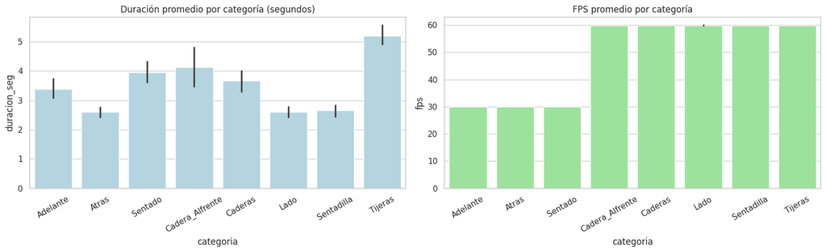

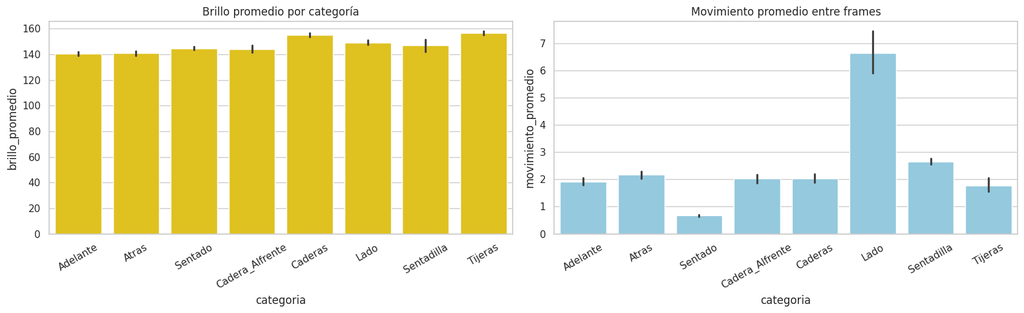

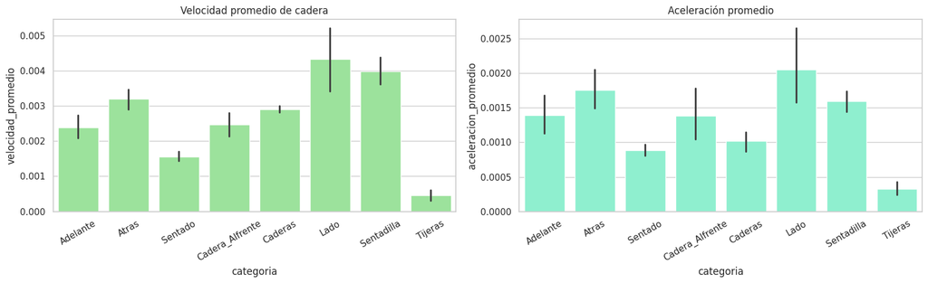

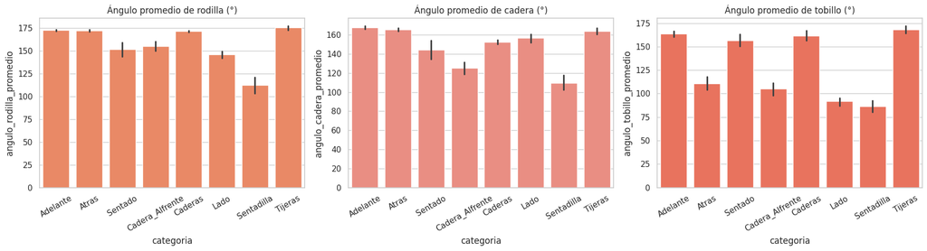

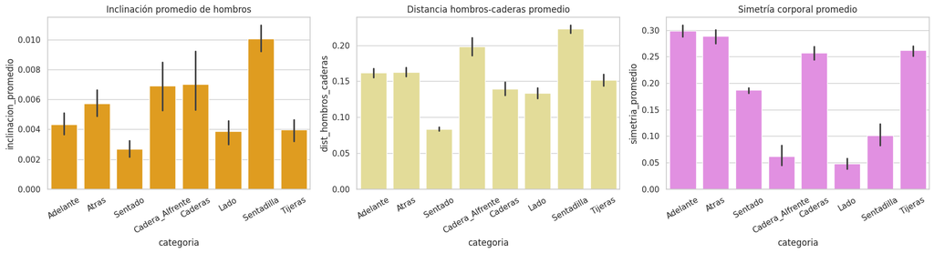

```python
sns.set(style="whitegrid", palette="muted")

# --- Duración y FPS ---
fig, axes = plt.subplots(1, 2, figsize=(16, 5))
sns.barplot(x="categoria", y="duracion_seg", data=df, ax=axes[0], color="lightblue")
sns.barplot(x="categoria", y="fps", data=df, ax=axes[1], color="lightgreen")
axes[0].set_title("Duración promedio por categoría (segundos)")
axes[1].set_title("FPS promedio por categoría")
for ax in axes:
    ax.tick_params(axis='x', rotation=30)
plt.tight_layout()
plt.show()

# --- Brillo y Movimiento ---
fig, axes = plt.subplots(1, 2, figsize=(16, 5))
sns.barplot(x="categoria", y="brillo_promedio", data=df, ax=axes[0], color="gold")
sns.barplot(x="categoria", y="movimiento_promedio", data=df, ax=axes[1], color="skyblue")
axes[0].set_title("Brillo promedio por categoría")
axes[1].set_title("Movimiento promedio entre frames")
for ax in axes:
    ax.tick_params(axis='x', rotation=30)
plt.tight_layout()
plt.show()

# --- Velocidad y Aceleración ---
fig, axes = plt.subplots(1, 2, figsize=(16, 5))
sns.barplot(x="categoria", y="velocidad_promedio", data=df, ax=axes[0], color="lightgreen")
sns.barplot(x="categoria", y="aceleracion_promedio", data=df, ax=axes[1], color="aquamarine")
axes[0].set_title("Velocidad promedio de cadera")
axes[1].set_title("Aceleración promedio")
for ax in axes:
    ax.tick_params(axis='x', rotation=30)
plt.tight_layout()
plt.show()

# --- Ángulos biomecánicos ---
fig, axes = plt.subplots(1, 3, figsize=(18, 5))
sns.barplot(x="categoria", y="angulo_rodilla_promedio", data=df, ax=axes[0], color="coral")
sns.barplot(x="categoria", y="angulo_cadera_promedio", data=df, ax=axes[1], color="salmon")
sns.barplot(x="categoria", y="angulo_tobillo_promedio", data=df, ax=axes[2], color="tomato")
axes[0].set_title("Ángulo promedio de rodilla (°)")
axes[1].set_title("Ángulo promedio de cadera (°)")
axes[2].set_title("Ángulo promedio de tobillo (°)")
for ax in axes:
    ax.tick_params(axis='x', rotation=30)
plt.tight_layout()
plt.show()

# --- Inclinación, distancia y simetría corporal ---
fig, axes = plt.subplots(1, 3, figsize=(18, 5))
sns.barplot(x="categoria", y="inclinacion_promedio", data=df, ax=axes[0], color="orange")
sns.barplot(x="categoria", y="dist_hombros_caderas", data=df, ax=axes[1], color="khaki")
sns.barplot(x="categoria", y="simetria_promedio", data=df, ax=axes[2], color="violet")
axes[0].set_title("Inclinación promedio de hombros")
axes[1].set_title("Distancia hombros-caderas promedio")
axes[2].set_title("Simetría corporal promedio")
for ax in axes:
    ax.tick_params(axis='x', rotation=30)
plt.tight_layout()
plt.show()
```

En conclusión, los gráficos muestran una coherencia entre los valores de cada métrica y la naturaleza física del movimiento, validando la capacidad del sistema para diferenciar posturas y patrones de acción mediante los landmarks corporales.

```python
# --- Estadísticas generales ---
display(df.describe())

print("\n Observaciones generales:")
print(f"- Promedio de FPS: {df['fps'].mean():.2f}")
print(f"- Duración promedio: {df['duracion_seg'].mean():.2f} s")
print(f"- Brillo promedio: {df['brillo_promedio'].mean():.2f}")
print(f"- Movimiento promedio: {df['movimiento_promedio'].mean():.2f}")
print(f"- Velocidad promedio de cadera: {df['velocidad_promedio'].mean():.4f}")
print(f"- Aceleración promedio: {df['aceleracion_promedio'].mean():.4f}")
print(f"- Ángulo promedio de rodilla: {df['angulo_rodilla_promedio'].mean():.2f}°")
print(f"- Ángulo promedio de cadera: {df['angulo_cadera_promedio'].mean():.2f}°")
print(f"- Ángulo promedio de tobillo: {df['angulo_tobillo_promedio'].mean():.2f}°")
print(f"- Inclinación promedio de hombros: {df['inclinacion_promedio'].mean():.4f}")
print(f"- Distancia hombros-caderas promedio: {df['dist_hombros_caderas'].mean():.4f}")
print(f"- Simetría corporal promedio: {df['simetria_promedio'].mean():.4f}")
```

|  | fps | frames | duracion_seg | brillo_promedio | movimiento_promedio | velocidad_promedio | aceleracion_promedio | angulo_rodilla_promedio | angulo_cadera_promedio | angulo_tobillo_promedio | inclinacion_promedio | dist_hombros_caderas | simetria_promedio |
| --- | --- | --- | --- | --- | --- | --- | --- | --- | --- | --- | --- | --- | --- |
| count | 86.000000 | 86.00000 | 86.000000 | 86.000000 | 86.000000 | 86.000000 | 86.000000 | 86.000000 | 86.000000 | 86.000000 | 86.000000 | 86.000000 | 86.000000 |
| mean | 41.138256 | 144.22093 | 3.445814 | 145.161395 | 2.105349 | 0.002534 | 0.001312 | 160.385465 | 152.604651 | 135.902326 | 0.005065 | 0.148917 | 0.217000 |
| std | 14.553885 | 74.00690 | 0.972798 | 6.370730 | 1.433218 | 0.001176 | 0.000661 | 19.854028 | 20.490725 | 32.111323 | 0.002618 | 0.041976 | 0.090716 |
| min | 30.000000 | 62.00000 | 2.070000 | 133.770000 | 0.540000 | 0.000200 | 0.000200 | 97.230000 | 91.180000 | 73.390000 | 0.000800 | 0.071400 | 0.031700 |
| 25% | 30.000000 | 89.25000 | 2.722500 | 140.225000 | 1.505000 | 0.001600 | 0.000825 | 152.010000 | 141.250000 | 103.880000 | 0.003150 | 0.132050 | 0.170900 |
| 50% | 30.000000 | 121.00000 | 3.150000 | 145.395000 | 2.005000 | 0.002600 | 0.001200 | 170.690000 | 162.885000 | 149.915000 | 0.004500 | 0.150500 | 0.254650 |
| 75% | 59.930000 | 174.00000 | 4.085000 | 148.110000 | 2.347500 | 0.003425 | 0.001675 | 173.092500 | 167.455000 | 165.162500 | 0.006625 | 0.171400 | 0.289125 |
| max | 59.960000 | 366.00000 | 6.110000 | 158.360000 | 7.960000 | 0.006100 | 0.003700 | 177.540000 | 175.390000 | 174.860000 | 0.012200 | 0.231500 | 0.340800 |

```
 Observaciones generales:
- Promedio de FPS: 41.14
- Duración promedio: 3.45 s
- Brillo promedio: 145.16
- Movimiento promedio: 2.11
- Velocidad promedio de cadera: 0.0025
- Aceleración promedio: 0.0013
- Ángulo promedio de rodilla: 160.39°
- Ángulo promedio de cadera: 152.60°
- Ángulo promedio de tobillo: 135.90°
- Inclinación promedio de hombros: 0.0051
- Distancia hombros-caderas promedio: 0.1489
- Simetría corporal promedio: 0.2170
```

### **Análisis de Resultados con Landmarks**

El sistema desarrollado procesa cada cuadro del video utilizando MediaPipe Pose, que detecta un conjunto de landmarks corporales (hombros, codos, caderas, rodillas y tobillos). A partir de esos puntos de referencia, se ejecuta un conjunto de operaciones matemáticas que permiten medir dinámicamente la postura y el movimiento humano:

En conclusión, el análisis de los landmarks permite reconstruir y comprender la dinámica corporal de manera precisa.

## **Análisis Exploratorio de los Datos**

### **Cargar los datos**

```python
# Cargar datos
csv_path = "/content/drive/MyDrive/APO3_EntregaFinal/Entrega2/resultados/analisis_videos_con_landmarks.csv"
df = pd.read_csv(csv_path)

print("Dimensiones del dataset:", df.shape)
df.head()
```

```
Dimensiones del dataset: (86, 16)
```

|  | categoria | video | fps | frames | duracion_seg | resolucion | brillo_promedio | movimiento_promedio | velocidad_promedio | aceleracion_promedio | angulo_rodilla_promedio | angulo_cadera_promedio | angulo_tobillo_promedio | inclinacion_promedio | dist_hombros_caderas | simetria_promedio |
| --- | --- | --- | --- | --- | --- | --- | --- | --- | --- | --- | --- | --- | --- | --- | --- | --- |
| 0 | Adelante | adelante1.mp4 | 30.0 | 102 | 3.40 | 1080x1908 | 143.88 | 1.76 | 0.0016 | 0.0007 | 175.53 | 175.39 | 169.23 | 0.0028 | 0.1388 | 0.2555 |
| 1 | Adelante | adelante2.mp4 | 30.0 | 102 | 3.40 | 1080x1908 | 137.84 | 2.40 | 0.0040 | 0.0025 | 173.88 | 168.36 | 166.13 | 0.0026 | 0.1625 | 0.2892 |
| 2 | Adelante | adelante3.mp4 | 30.0 | 82 | 2.73 | 1080x1908 | 141.12 | 1.64 | 0.0026 | 0.0024 | 173.81 | 167.44 | 162.71 | 0.0030 | 0.1362 | 0.2594 |
| 3 | Adelante | adelante4.mp4 | 30.0 | 117 | 3.90 | 1080x1908 | 145.50 | 2.04 | 0.0023 | 0.0012 | 171.97 | 165.66 | 149.57 | 0.0031 | 0.1690 | 0.3248 |
| 4 | Adelante | adelante5.mp4 | 30.0 | 111 | 3.70 | 1080x1908 | 139.31 | 1.82 | 0.0016 | 0.0008 | 171.04 | 164.59 | 159.88 | 0.0037 | 0.1671 | 0.3099 |

```python
df.info()
print("\nValores nulos por columna:\n" , df.isnull().sum())
```

```
<class 'pandas.core.frame.DataFrame'>
RangeIndex: 86 entries, 0 to 85
Data columns (total 16 columns):
 #   Column                   Non-Null Count  Dtype
---  ------                   --------------  -----
 0   categoria                86 non-null     object
 1   video                    86 non-null     object
 2   fps                      86 non-null     float64
 3   frames                   86 non-null     int64
 4   duracion_seg             86 non-null     float64
 5   resolucion               86 non-null     object
 6   brillo_promedio          86 non-null     float64
 7   movimiento_promedio      86 non-null     float64
 8   velocidad_promedio       86 non-null     float64
 9   aceleracion_promedio     86 non-null     float64
 10  angulo_rodilla_promedio  86 non-null     float64
 11  angulo_cadera_promedio   86 non-null     float64
 12  angulo_tobillo_promedio  86 non-null     float64
 13  inclinacion_promedio     86 non-null     float64
 14  dist_hombros_caderas     86 non-null     float64
 15  simetria_promedio        86 non-null     float64
dtypes: float64(12), int64(1), object(3)
memory usage: 10.9+ KB

Valores nulos por columna:
 categoria                  0
video                      0
fps                        0
frames                     0
duracion_seg               0
resolucion                 0
brillo_promedio            0
movimiento_promedio        0
velocidad_promedio         0
aceleracion_promedio       0
angulo_rodilla_promedio    0
angulo_cadera_promedio     0
angulo_tobillo_promedio    0
inclinacion_promedio       0
dist_hombros_caderas       0
simetria_promedio          0
dtype: int64
```

```python
df.describe().T
```

|  | count | mean | std | min | 25% | 50% | 75% | max |
| --- | --- | --- | --- | --- | --- | --- | --- | --- |
| fps | 86.0 | 41.138256 | 14.553885 | 30.0000 | 30.000000 | 30.00000 | 59.930000 | 59.9600 |
| frames | 86.0 | 144.220930 | 74.006900 | 62.0000 | 89.250000 | 121.00000 | 174.000000 | 366.0000 |
| duracion_seg | 86.0 | 3.445814 | 0.972798 | 2.0700 | 2.722500 | 3.15000 | 4.085000 | 6.1100 |
| brillo_promedio | 86.0 | 145.161395 | 6.370730 | 133.7700 | 140.225000 | 145.39500 | 148.110000 | 158.3600 |
| movimiento_promedio | 86.0 | 2.105349 | 1.433218 | 0.5400 | 1.505000 | 2.00500 | 2.347500 | 7.9600 |
| velocidad_promedio | 86.0 | 0.002534 | 0.001176 | 0.0002 | 0.001600 | 0.00260 | 0.003425 | 0.0061 |
| aceleracion_promedio | 86.0 | 0.001312 | 0.000661 | 0.0002 | 0.000825 | 0.00120 | 0.001675 | 0.0037 |
| angulo_rodilla_promedio | 86.0 | 160.385465 | 19.854028 | 97.2300 | 152.010000 | 170.69000 | 173.092500 | 177.5400 |
| angulo_cadera_promedio | 86.0 | 152.604651 | 20.490725 | 91.1800 | 141.250000 | 162.88500 | 167.455000 | 175.3900 |
| angulo_tobillo_promedio | 86.0 | 135.902326 | 32.111323 | 73.3900 | 103.880000 | 149.91500 | 165.162500 | 174.8600 |
| inclinacion_promedio | 86.0 | 0.005065 | 0.002618 | 0.0008 | 0.003150 | 0.00450 | 0.006625 | 0.0122 |
| dist_hombros_caderas | 86.0 | 0.148917 | 0.041976 | 0.0714 | 0.132050 | 0.15050 | 0.171400 | 0.2315 |
| simetria_promedio | 86.0 | 0.217000 | 0.090716 | 0.0317 | 0.170900 | 0.25465 | 0.289125 | 0.3408 |

### **Limpiza de datos**

Elimina columnas redundantes o que no aportan al modelo.

```python
# Eliminar solo las columnas no útiles para el modelado
df_model = df.drop(columns=["video", "resolucion", "fps"])

# Verificar estructura
print("Estructura del dataset limpio para modelado:")
print(df_model.info())
display(df_model.head())

# Guardar dataset limpio
clean_path = os.path.join(RESULTADOS_PATH, "dataset_limpio.csv")
df_model.to_csv(clean_path, index=False)
print(f"Dataset limpio guardado en: {clean_path}")
```

```
Estructura del dataset limpio para modelado:
<class 'pandas.core.frame.DataFrame'>
RangeIndex: 86 entries, 0 to 85
Data columns (total 13 columns):
 #   Column                   Non-Null Count  Dtype
---  ------                   --------------  -----
 0   categoria                86 non-null     object
 1   frames                   86 non-null     int64
 2   duracion_seg             86 non-null     float64
 3   brillo_promedio          86 non-null     float64
 4   movimiento_promedio      86 non-null     float64
 5   velocidad_promedio       86 non-null     float64
 6   aceleracion_promedio     86 non-null     float64
 7   angulo_rodilla_promedio  86 non-null     float64
 8   angulo_cadera_promedio   86 non-null     float64
 9   angulo_tobillo_promedio  86 non-null     float64
 10  inclinacion_promedio     86 non-null     float64
 11  dist_hombros_caderas     86 non-null     float64
 12  simetria_promedio        86 non-null     float64
dtypes: float64(11), int64(1), object(1)
memory usage: 8.9+ KB
None
```

|  | categoria | frames | duracion_seg | brillo_promedio | movimiento_promedio | velocidad_promedio | aceleracion_promedio | angulo_rodilla_promedio | angulo_cadera_promedio | angulo_tobillo_promedio | inclinacion_promedio | dist_hombros_caderas | simetria_promedio |
| --- | --- | --- | --- | --- | --- | --- | --- | --- | --- | --- | --- | --- | --- |
| 0 | Adelante | 102 | 3.40 | 143.88 | 1.76 | 0.0016 | 0.0007 | 175.53 | 175.39 | 169.23 | 0.0028 | 0.1388 | 0.2555 |
| 1 | Adelante | 102 | 3.40 | 137.84 | 2.40 | 0.0040 | 0.0025 | 173.88 | 168.36 | 166.13 | 0.0026 | 0.1625 | 0.2892 |
| 2 | Adelante | 82 | 2.73 | 141.12 | 1.64 | 0.0026 | 0.0024 | 173.81 | 167.44 | 162.71 | 0.0030 | 0.1362 | 0.2594 |
| 3 | Adelante | 117 | 3.90 | 145.50 | 2.04 | 0.0023 | 0.0012 | 171.97 | 165.66 | 149.57 | 0.0031 | 0.1690 | 0.3248 |
| 4 | Adelante | 111 | 3.70 | 139.31 | 1.82 | 0.0016 | 0.0008 | 171.04 | 164.59 | 159.88 | 0.0037 | 0.1671 | 0.3099 |

```
Dataset limpio guardado en: /content/drive/MyDrive/APO3_EntregaFinal/Entrega2/resultados/dataset_limpio.csv
```

Tras la revisión inicial del dataset generado en la etapa de procesamiento con landmarks, se comprobó que **no existían valores nulos ni inconsistencias** en los registros, lo cual garantizó la calidad del conjunto de datos.

- **Brillo promedio:** indicador de las condiciones de iluminación y estabilidad visual del video.
- **Movimiento promedio:** mide la variación de píxeles entre cuadros consecutivos, asociado al grado de actividad.
- **Velocidad promedio:** refleja el desplazamiento del punto medio entre caderas, útil para analizar ritmo y control del movimiento.
- **Ángulo promedio de rodilla:** describe el nivel de flexión o extensión de las piernas, relevante en acciones como sentarse o caminar.
- **Inclinación promedio:** estima el desbalance postural mediante la diferencia vertical entre los hombros.

Estas métricas se consideran las **features principales** que caracterizan las diferentes categorías del movimiento humano. Con esto se conformó un dataset limpio y estructurado, listo para la fase de **análisis exploratorio y modelado supervisado**.

### **Normalización de variables**

Una vez depurado el dataset, se procedió a normalizar las variables numéricas con el objetivo de equilibrar sus escalas y evitar sesgos en el proceso de entrenamiento de los modelos. Se aplicó el método MinMaxScaler, que transforma los valores de cada variable a un rango entre 0 y 1, manteniendo las proporciones relativas entre observaciones.

Esto fue necesario debido a que las métricas como el brillo promedio (con valores alrededor de 140) y la velocidad promedio (en el orden de 0.002) estaban en magnitudes muy diferentes, lo cual podría afectar el desempeño de algoritmos sensibles a la escala de los datos.

Con esta normalización, las variables quedaron homogéneamente distribuidas, permitiendo que cada una tenga un peso comparable en el análisis y modelado. De esta manera, el dataset quedó listo para la siguiente fase de entrenamiento de modelos supervisados, asegurando la estabilidad y equidad en el tratamiento de las características numéricas.

```python
# Copia del dataset limpio
df_norm = df_model.copy()

# Seleccionar columnas numéricas (excluyendo la categoría)
cols_numericas = df_norm.select_dtypes(include=["float64", "int64"]).columns
cols_numericas = [c for c in cols_numericas if c != "categoria"]

# Aplicar MinMaxScaler
scaler = MinMaxScaler()
df_norm[cols_numericas] = scaler.fit_transform(df_norm[cols_numericas])

# Mostrar resultados
print("Normalización completada.")
display(df_norm.head())

# Guardar dataset normalizado
norm_path = os.path.join(BASE_PATH, "resultados", "dataset_normalizado.csv")
df_norm.to_csv(norm_path, index=False)
print(f"Dataset normalizado guardado en: {norm_path}")
```

```
Normalización completada.
```

|  | categoria | frames | duracion_seg | brillo_promedio | movimiento_promedio | velocidad_promedio | aceleracion_promedio | angulo_rodilla_promedio | angulo_cadera_promedio | angulo_tobillo_promedio | inclinacion_promedio | dist_hombros_caderas | simetria_promedio |
| --- | --- | --- | --- | --- | --- | --- | --- | --- | --- | --- | --- | --- | --- |
| 0 | Adelante | 0.131579 | 0.329208 | 0.411143 | 0.164420 | 0.237288 | 0.142857 | 0.974972 | 1.000000 | 0.944516 | 0.175439 | 0.420987 | 0.724038 |
| 1 | Adelante | 0.131579 | 0.329208 | 0.165514 | 0.250674 | 0.644068 | 0.657143 | 0.954427 | 0.916518 | 0.913965 | 0.157895 | 0.569019 | 0.833064 |
| 2 | Adelante | 0.065789 | 0.163366 | 0.298902 | 0.148248 | 0.406780 | 0.628571 | 0.953555 | 0.905593 | 0.880260 | 0.192982 | 0.404747 | 0.736655 |
| 3 | Adelante | 0.180921 | 0.452970 | 0.477023 | 0.202156 | 0.355932 | 0.285714 | 0.930644 | 0.884456 | 0.750764 | 0.201754 | 0.609619 | 0.948237 |
| 4 | Adelante | 0.161184 | 0.403465 | 0.225295 | 0.172507 | 0.237288 | 0.171429 | 0.919064 | 0.871749 | 0.852370 | 0.254386 | 0.597751 | 0.900032 |

```
Dataset normalizado guardado en: /content/drive/MyDrive/APO3_EntregaFinal/Entrega2/resultados/dataset_normalizado.csv
```

### **Visualización de correlaciones**

Para eliminar redundancia entre métricas, analiza la correlación de variables numéricas.

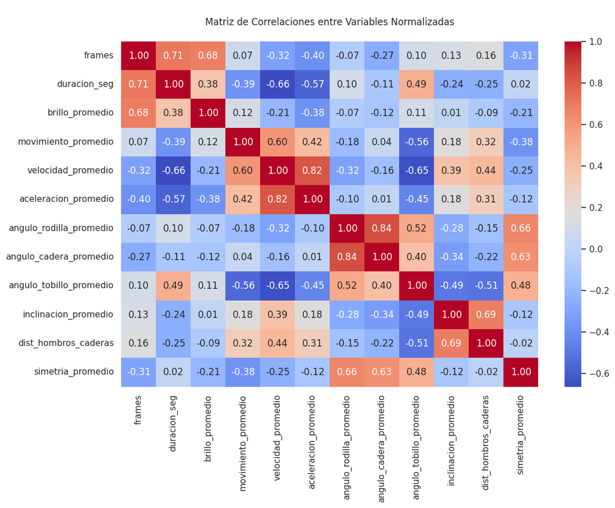

```
 Correlaciones más relevantes (>|0.7|):
```

|  |  | 0 |
| --- | --- | --- |
| angulo_cadera_promedio | angulo_rodilla_promedio | 0.844297 |
| velocidad_promedio | aceleracion_promedio | 0.823193 |
| duracion_seg | frames | 0.711537 |

**dtype:** float64

```python
# Calcular matriz de correlación
corr_matrix = df_norm.select_dtypes(include=["float64", "int64"]).corr()

# Mapa de calor
plt.figure(figsize=(12, 8))
sns.heatmap(corr_matrix, annot=True, cmap="coolwarm", fmt=".2f")
plt.title("\nMatriz de Correlaciones entre Variables Normalizadas\n")
plt.show()

# Mostrar las correlaciones más altas (excepto con sí mismas)
corr_pairs = (
    corr_matrix.unstack()
    .sort_values(ascending=False)
    .drop_duplicates()
)

print("\n Correlaciones más relevantes (>|0.7|):")
display(corr_pairs[(corr_pairs < 1) & (abs(corr_pairs) > 0.7)])
```

La matriz de correlaciones confirma la consistencia del conjunto de variables cinemáticas, mostrando relaciones esperadas entre métricas de movimiento y ángulos articulares. Se identifican grupos de variables con comportamientos similares (frames-duración y velocidad-aceleración), lo cual puede ser aprovechado en la etapa de selección de features o reducción de dimensionalidad (por ejemplo, PCA). La diversidad de correlaciones sugiere que el dataset es informativo y adecuado para entrenar modelos supervisados de clasificación de posturas.

### **Distribución de variables por categoría (Gráficos)**

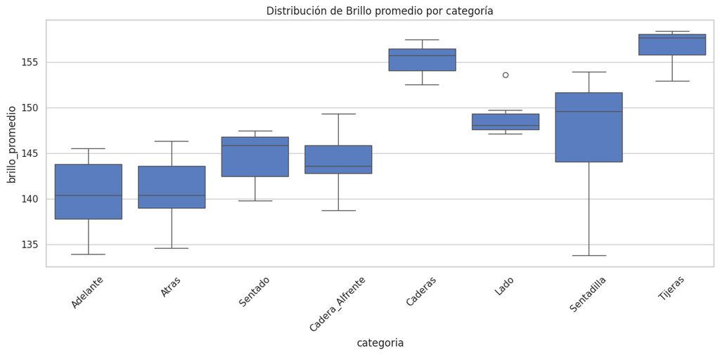

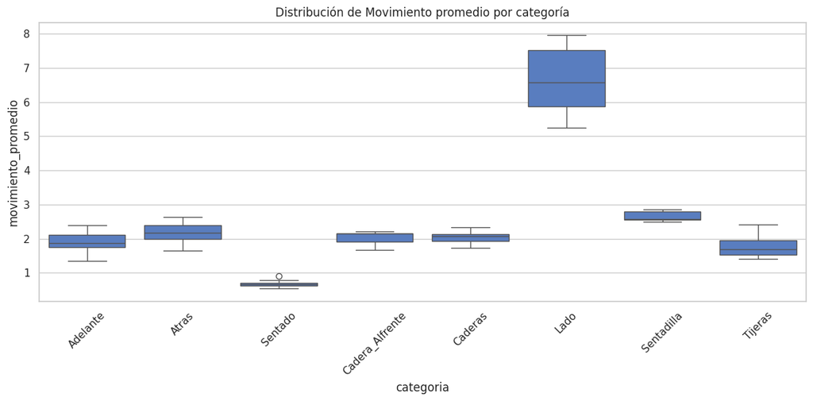

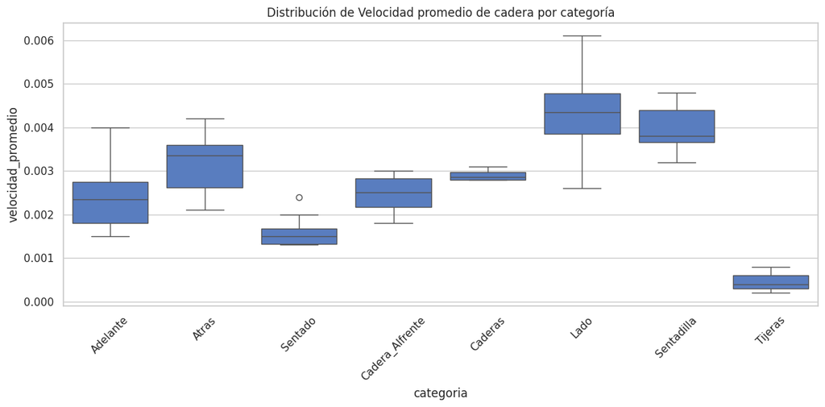

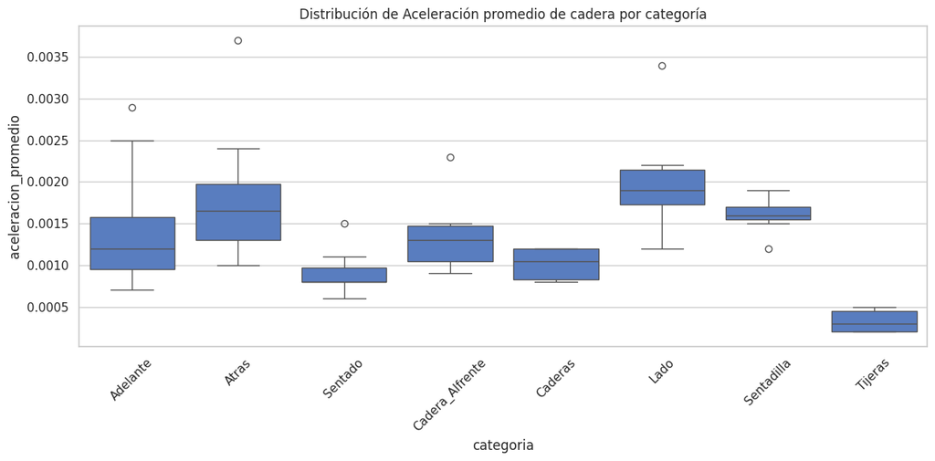

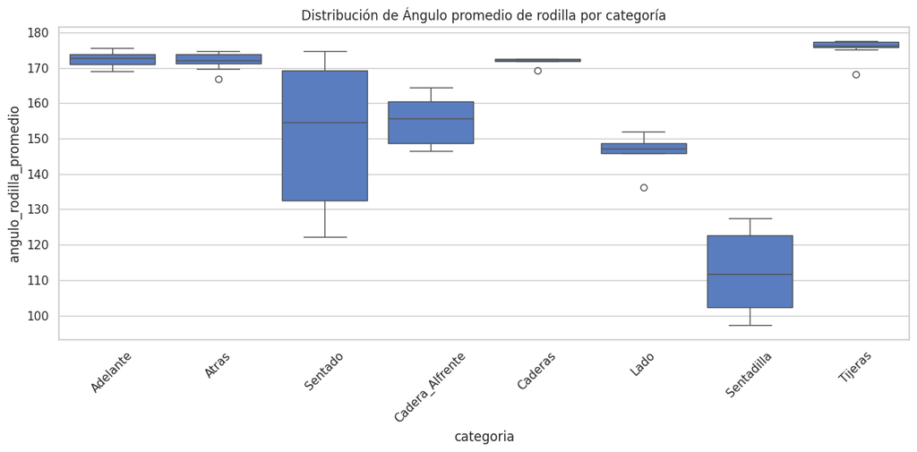

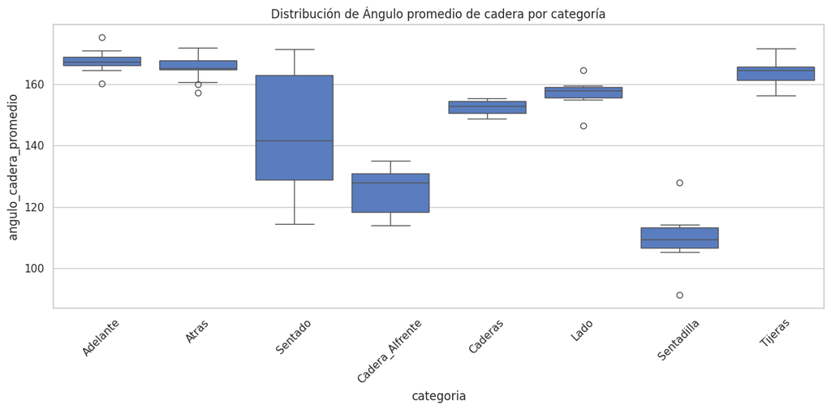

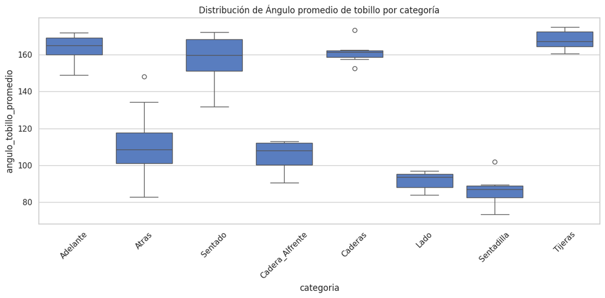

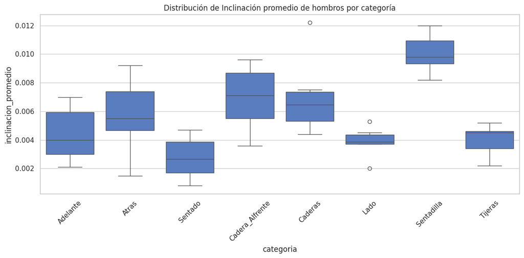

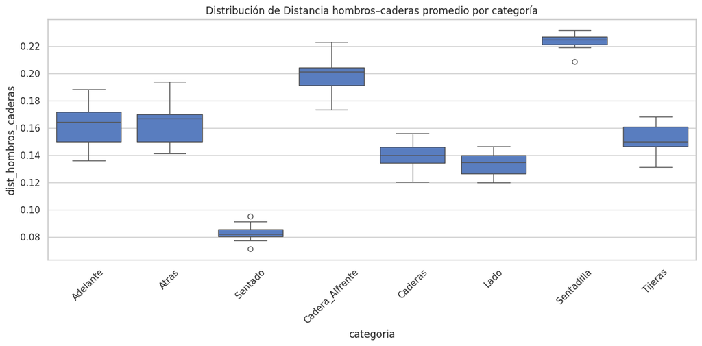

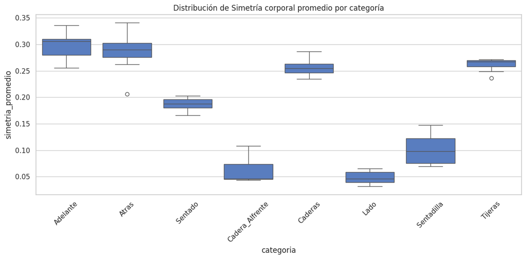

```python
# Configuración general
sns.set(style="whitegrid", palette="muted")

# Variables biomecánicas clave
variables = [
    ('brillo_promedio', 'Brillo promedio por categoría'),
    ('movimiento_promedio', 'Movimiento promedio por categoría'),
    ('velocidad_promedio', 'Velocidad promedio de cadera por categoría'),
    ('aceleracion_promedio', 'Aceleración promedio de cadera por categoría'),
    ('angulo_rodilla_promedio', 'Ángulo promedio de rodilla por categoría'),
    ('angulo_cadera_promedio', 'Ángulo promedio de cadera por categoría'),
    ('angulo_tobillo_promedio', 'Ángulo promedio de tobillo por categoría'),
    ('inclinacion_promedio', 'Inclinación promedio de hombros por categoría'),
    ('dist_hombros_caderas', 'Distancia hombros–caderas promedio por categoría'),
    ('simetria_promedio', 'Simetría corporal promedio por categoría')
]

# Crear los boxplots
for col, title in variables:
    plt.figure(figsize=(12,6))
    sns.boxplot(x='categoria', y=col, data=df)
    plt.title(f"Distribución de {title}")
    plt.xticks(rotation=45)
    plt.tight_layout()
    plt.show()
```